# The Cash Counties of PA

Dominick Weakley

```r
tracts <- read_csv("https://raw.githubusercontent.com/statsmaths/stat_data/gh-pages/acs_tract_data_2016.csv.gz")
```

```r
new_tracts <- filter(tracts, cbsa == "Pittsburgh, PA")
new_tracts
```

| state | county | cbsa | lon | lat | population | hh_income_q1 | hh_income_q2 | hh_income_q3 | hh_income_q4 | hh_income_q5 | hh_income_top_5 | hh_gini | median_rent | sex_male | sex_female | age_00_17 | age_18_24 | age_25_59 | age_60_plus | race_white | race_black | race_ntvam | race_asian | race_pacif | race_other | race_multi | born_same_st | born_other_ne | born_other_midwest | … |
| --- | --- | --- | --- | --- | --- | --- | --- | --- | --- | --- | --- | --- | --- | --- | --- | --- | --- | --- | --- | --- | --- | --- | --- | --- | --- | --- | --- | --- | --- | --- |
| Pennsylvania | Washington County | Pittsburgh, PA | -80.24664 | 40.16922 | 1761 | 6262 | 10243 | 14650 | 20363 | 43474 | 61384 | 0.3819 | 407 | 63.37 | 36.63 | 7.50 | 34.81 | 43.16 | 14.54 | 71.04 | 18.57 | 0.00 | 1.36 | 0.00 | 0.00 | 9.03 | 77.03 | 9.70 | 4.67 | … |
| Pennsylvania | Washington County | Pittsburgh, PA | -80.23583 | 40.36915 | 1624 | 12859 | 29969 | 43839 | 61998 | 110248 | 141861 | 0.3688 | 807 | 50.74 | 49.26 | 18.04 | 6.90 | 42.61 | 32.45 | 97.97 | 1.72 | 0.00 | 0.12 | 0.00 | 0.00 | 0.18 | 85.11 | 1.58 | 3.72 | … |
| Pennsylvania | Washington County | Pittsburgh, PA | -80.25928 | 40.18173 | 2568 | 13233 | 30656 | 51113 | 73780 | 131444 | 184717 | 0.3954 | 671 | 49.49 | 50.51 | 15.62 | 7.17 | 56.27 | 20.95 | 85.55 | 5.65 | 0.00 | 0.00 | 0.00 | 0.47 | 8.33 | 82.36 | 1.55 | 8.16 | … |
| Pennsylvania | Washington County | Pittsburgh, PA | -79.86198 | 40.17165 | 2343 | 7950 | 22613 | 41830 | 64209 | 117194 | 202345 | 0.4420 | 584 | 45.97 | 54.03 | 24.07 | 14.55 | 35.17 | 26.21 | 83.18 | 7.34 | 0.00 | 0.00 | 0.00 | 0.38 | 9.09 | 87.97 | 0.74 | 3.06 | … |
| Pennsylvania | Westmoreland County | Pittsburgh, PA | -79.76476 | 40.57567 | 1606 | 7418 | 17485 | 34794 | 57334 | 90955 | 103157 | 0.4142 | 737 | 38.23 | 61.77 | 27.02 | 10.09 | 41.47 | 21.42 | 52.18 | 39.23 | 0.00 | 0.00 | 0.00 | 1.62 | 6.97 | 92.03 | 4.89 | 1.19 | … |
| Pennsylvania | Westmoreland County | Pittsburgh, PA | -79.75705 | 40.59038 | 1519 | 14548 | 30993 | 44843 | 66838 | 124068 | 177340 | 0.3856 | 696 | 45.16 | 54.84 | 12.05 | 7.37 | 54.90 | 25.67 | 90.85 | 1.65 | 6.19 | 1.12 | 0.00 | 0.00 | 0.20 | 92.56 | 0.94 | 3.68 | … |
| Pennsylvania | Westmoreland County | Pittsburgh, PA | -79.55830 | 40.60302 | 1293 | 7102 | 19929 | 38548 | 60692 | 117895 | 157362 | 0.4535 | 605 | 48.72 | 51.28 | 22.20 | 4.18 | 50.50 | 23.12 | 84.07 | 11.76 | 1.08 | 0.00 | 0.00 | 0.00 | 3.09 | 81.88 | 2.26 | 5.37 | … |
| Pennsylvania | Westmoreland County | Pittsburgh, PA | -79.61196 | 40.31677 | 1981 | 15086 | 30772 | 45774 | 64224 | 147412 | 278535 | 0.4313 | 786 | 48.51 | 51.49 | 16.20 | 7.72 | 43.82 | 32.26 | 94.09 | 3.08 | 0.00 | 0.56 | 0.00 | 0.45 | 1.82 | 88.58 | 1.64 | 2.15 | … |
| Pennsylvania | Westmoreland County | Pittsburgh, PA | -79.53332 | 40.29717 | 3972 | 10463 | 27514 | 47302 | 68788 | 111052 | 161079 | 0.3886 | 699 | 44.08 | 55.92 | 20.37 | 6.82 | 42.75 | 30.06 | 89.00 | 8.08 | 0.00 | 0.86 | 0.00 | 0.00 | 2.06 | 86.23 | 2.72 | 5.33 | … |
| Pennsylvania | Westmoreland County | Pittsburgh, PA | -79.59275 | 40.09833 | 1947 | 11670 | 26380 | 44593 | 64880 | 111139 | 142244 | 0.3861 | 567 | 47.51 | 52.49 | 19.83 | 6.47 | 48.02 | 25.68 | 94.71 | 4.26 | 0.00 | 0.00 | 0.00 | 0.00 | 1.03 | 87.13 | 1.65 | 6.67 | … |

[output cut: 670 more lines]

```r
county_tracts <- group_summarize(new_tracts, county)
county_tracts
```

[output not shown]

## Introduction

Wealth disparity has been a hotly debated issue in the United States for around for as long as I can remember. Politicians from both the left and right waste no time weighing in on the issue, offering the public thousands of theories to why this happened and how. I’ve grown extremely tired hearing all of the speeches and plans these politicians have. Thus, I have decided to take an in-depth statistical analysis of wealth disparity, investigating where wealth disparity is greatest and why. With statistics indicating that the top 10 wealthiest percent of population control 75 percent of the wealth and the lowest 70 percent the populist control only 6.9 percent of the wealth. I want to focus my attention on the potential social factors that affect wealth disparity. I chose to focus on the wealth disparity in the working class city of Pittsburgh, PA. More specifically I want to focus on the disparity of wealth in the seven different counties that make up the greater Pittsburgh. To calculate the wealth disparity I will be using the Gini coefficient. The Gini coefficient is a measure of statistical dispersion intended to represent the income or wealth distribution of a nation’s residents and is the most commonly used measure of inequality. The closer the Gini coefficient is to 1 the greater the disparity.

## Analysis

As seen below both Fayette and Allegheny County serve as anomalies when comparing the mean Gini coefficient. Fayette and Allegheny are the only counties to have a Gini coefficient over .435, with the next highest county, Washington, earning a .416 coefficient.

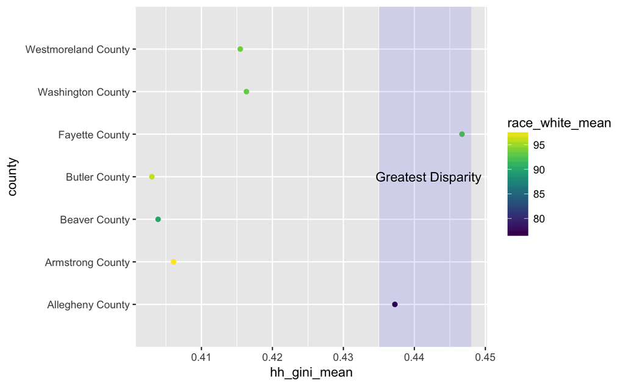

```r
ggplot(county_tracts, aes(hh_gini_mean, county))+
  geom_point(aes(color = race_white_mean)) +
  scale_color_viridis() +
  annotate("rect", xmin = 0.435, xmax = 0.448,
           ymin = 0, ymax = 8,
           fill = "blue", alpha = 0.1) +
  annotate("text", x = .442, y = 4,
           label = "Greatest Disparity")
```

```r
NA
NA
```

Since Fayette and Allegheny counties have the greatest wealth disparity in the greater Pittsburgh area, exploring the demographics of the two countries is vital to understanding the potential social factors that affect wealth disparity in the United States. The county of Fayette has the greatest mean disparity of any Pittsburgh county, but as the scale above indicates may not have to do with racial demographics. With a reported 92.6% white population, Fayette County is a middle of the road county in terms of demographics. Fayette’s disparity in wealth most likely stems from other social factors we will explore below. Allegheny, on the other hand, is reported to be 76.5% white, the lowest percentage of any county by 13%. Since the difference in demographics is so extremely different for Allegheny county when compared to the other Pittsburgh counties I can logically conclude that in Allegheny county wealth disparity runs along racial lines.

Differences in racial demographics are not the only potential factor that affects the wealth disparity of a city or county. Different gender divides in among a population may also play an important role. Since the average female worker earns only 81.3% of what the average male makes the gender difference in a county could greatly affect the wealth distribution.

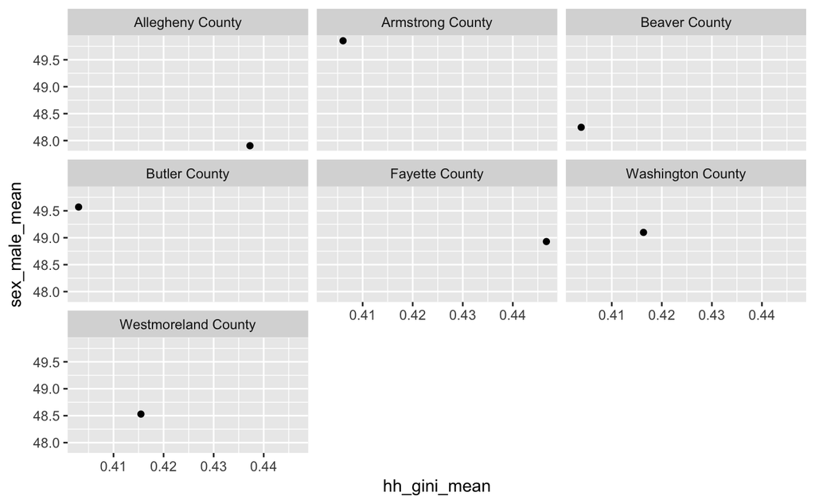

```r
ggplot(county_tracts,aes(hh_gini_mean, sex_male_mean)) +
  geom_point() +
  facet_wrap(~county)
```

The final factor that I will be investigating that can affect wealth disparity is not directly linked to demographics but is based on location. Allegheny County is the most densely populated county in the data group, encompassing downtown Pittsburgh and most of its urban areas. The city of Pittsburgh shows a fiscally diverse populace expected of any city in the northeast. Allegheny county containing urban Pittsburgh, directly affects its wealth disparity, due to the diversity of work available in urban cities.

[output not shown]

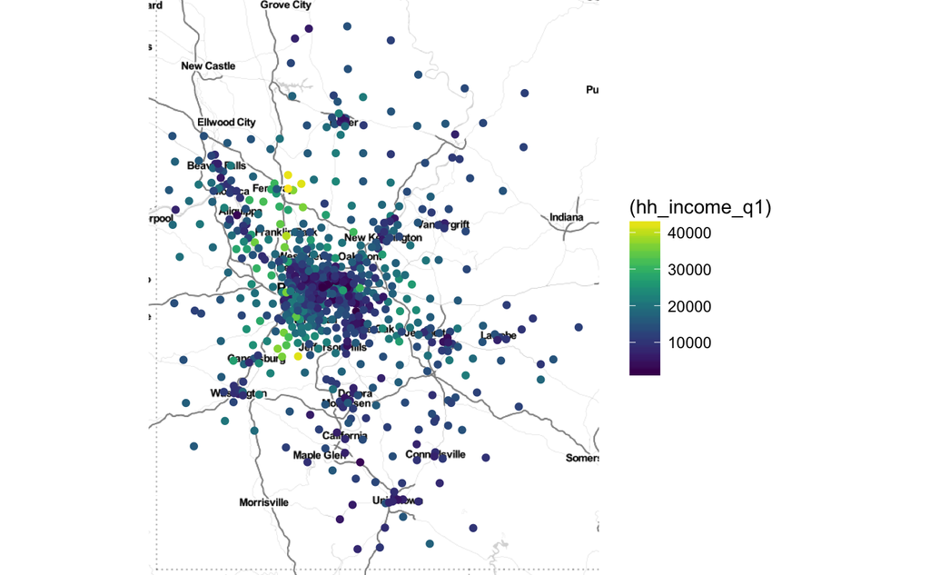

```r
qmplot(lon, lat, data = new_tracts, geom = "blank") +
  geom_point(aes(color = (hh_income_q1), alpa = 0.1)) +
  scale_color_viridis()
```

## References

All products require an annual contract. Prices do not include sales tax (New York residents only). “U.S. Wealth Distribution in 2017 | Statistic.” Statista, www.statista.com/statistics/203961/wealth-distribution-for-the-us/.

Doyle, Alison. “How Much Is the Average Salary for US Workers?” The Balance, www.thebalance.com/average-salary-information-for-us-workers-2060808.